# Trabalho Final - MQ: Domicílios chefiados por mulheres no Distrito Federal

Valeria, Lorena, Sofia, João Pedro

13/12/2020

# 1 Introdução

De acordo com o IBGE, o perfil familiar brasileiro mudou bastante nos últimos anos, a começar com o crescimento dos domicílios chefiados por mulheres, cujo percentual se aproxima daqueles chefiados por homens. A chefia feminina abrangeu 48,2% em 2019, enquanto a chefia masculina tem um percentual de 51,8%. Em 1995, por exemplo, somente 22% das famílias eram chefiadas por mulheres, portanto houve um aumento expressivo do número de mulheres responsáveis pelo domicílio. Contudo, a maior responsabilidade feminina pelas suas famílias não resultou em melhorias na renda e nas oportunidades de trabalho. Hoje, no Brasil, o que vemos é que as famílias chefiadas por mulheres estão mais concentradas em faixas de renda per capita baixa.

Uma faceta importante desse fenômeno é a existência de altos números de dependência econômica de domicílios chefiados por mulheres, demonstrando a importância da renda dessas mulheres para manter suas famílias. Em momentos de crise com a perda de renda emerge a situação de pobreza extrema desses domicílios (OIT e PNUD, 2009).

Estudo realizado por Felker-Kantor e Wood (2012) chegou a duas conclusões: a primeira, as mulheres possuem maior suscetibilidade à pobreza, pela forma pela qual ingressam no mercado de trabalho e sobrecarga de trabalhos domésticos. Segundo, que o trabalho feminino e o perfil de consumo feminino possuem efeito positivo sobre o bem-estar das crianças e dos demais membros dos domicílios.

Neste cenário, a questão fundamental é a adaptabilidade dos empregos informais às responsabilidades domésticas que as mulheres acabam assumindo pelo fato de serem mulheres. A ausência em relação a serviços sociais é uma das dimensões nas quais as mulheres acabam assumindo responsabilidades familiares, como cuidar de pessoas doentes, ou idosas e monitorar as atividades escolares dos filhos (OIT e PNUD, 2009). Ou seja, o trabalho não pago das mulheres sustenta grande parte da reprodução da força de trabalho do sistema econômico vigente.

As mulheres continuam em desvantagem em relação aos homens no campo do trabalho, mesmo quando têm mais anos de estudo e/ou qualificação profissional, em muitas empresas seus salários são inferiores aos dos homens que exercem a mesma função. A participação política ainda é muito inferior à dos homens. O exercício do trabalho doméstico, o cuidado de idosos e enfermos continua sendo em grande parte das mulheres. Ainda perdura na sociedade a ideia atrasada de que o homem tem poder sobre o corpo e a vida da mulher.

Na Pesquisa Distrital por Amostra de Domicílios (PDAD) de 2018, pode-se observar que há no Distrito Federal, assim como em outros estados brasileiros, uma significativa diferença entre homens e mulheres, com relação à inserção no mercado de trabalho, às atividades domésticas desempenhadas, e à média de renda e na qualidade e bem-estar de moradia. A diferença pode ser vista mesmo que as mulheres sejam a maioria da população do Distrito Federal, são 52% da população, cerca de 1.504.068. Elas aparecem como maior parcela da população em todas as faixas etárias a partir dos 25 anos.

# 2 Metodologia

A base de dados utilizada neste trabalho foi da Pesquisa Distrital por Amostra de Domicílios (PDAD) do ano de 2018 elaborada pela Companhia de Planejamento do Distrito Federal (Codeplan). Trata-se de uma pesquisa por amostragem de 21.908 domicílios urbanos selecionados mediante critério aleatório e probabilístico, de forma a garantir representatividade estatística para cada uma das Regiões Administrativas do Distrito Federal, de um universo de 883.509 domicílios urbanos. Os dados coletados para a PDAD fazem parte de um banco de dados, sem identificação dos moradores entrevistados. O objetivo desse levantamento é conhecer melhor a situação socioeconômica, demográfica, de migração, da condição social e econômica da população urbana residente no DF, além das características do domicílio e das condições de infraestrutura urbana. Para mais informações sobre a base de dados e o estudo PDAD/2018 consultar os resultados no site da [Codeplan](http://www.codeplan.df.gov.br/pdad-2018/).

O objetivo geral do presente trabalho é compreender a situação socioeconômica dos domicílios chefiados por mulheres no Distrito Federal. Mais especificamente, busca-se investigar a diferença entre as condições de infraestrutura urbana de domicílios chefiados por mulheres e homens. Para isso, serão criados indicadores e estatísticas descritivas usando como base de dados a PDAD 2018 referente às respostas por domicílios e de moradores. A hipótese central é de que o gênero da pessoa responsável pelo domicílio faz diferença nos índices de qualidade de infraestrutura urbana de domicílio no Distrito Federal.  
Vale ressaltar, para a caracterização de “chefe do domicílio” foi levado em consideração, dentro da base de dados com respostas dos moradores, aqueles que responderam “ser responsável pela residência”, sendo este o único critério para ser considerado chefe. Portanto, não foram consideradas categorias de renda dentro desta pesquisa.

## 2.1 Metodologia do Índice Urbano (IND)

Para análise da proposta, decidiu-se pela criação de um Índice Urbano (IND) que irá medir o nível de condições domiciliar urbana do Distrito Federal, com base em indicadores de infraestrutura e de serviços coletivos nas proximidades do domicílio. Suas dimensões são: - ID1: no entorno do domicílio não têm rede geral CAESB; - ID2: no entorno do domicílio a sua rua não tem calçada; - ID3: no entorno do domicílio na sua rua não tem iluminação; - ID4: no entorno do domicílio na sua rua não tem rede de água pluvial; - ID5: próximo a sua casa tem entulhos; - ID6: quando chove a sua rua fica alagada; - ID7: a sua rua é esburacada; - ID8: no entorno do domicílio não tem ruas arborizadas; - ID9: no entorno do domicílio não tem parques e jardins; - ID10: no entorno do domicílio não tem quadras esportivas.

O índice (IND )é calculado com base na soma das dimensões avaliadas: - IND = soma($ID_{i}$), em que i=1,…,10.

Os valores do índice (IND) são distribuídos na escala de zero a dez. Quanto menor o resultado, melhor são as condições de infraestrutura do domicílio. E quanto mais próximo de dez, maior são as fragilidades que o domicílio tem em relação aos serviços de utilidade pública.Foram estabelecidas três faixas de interpretação com os seguintes limites e classificação do índice:

```
##   Classificação.do.índice   Intervalo
## 1                     Bom        <= 3
## 2                   Médio entre 3 e 6
## 3                    Ruim        >= 6
```

# 3 Análise e resultados

## 3.1 Manipulação dos dados

**1. Importando Banco de dados: PDAD 2018**

- As informações foram acessadas pelo banco de dados da [Codeplan](http://codeplan.df.gov.br/codeplan-divulga-microdados-da-pdad-2018/)
- Foram coletados dois banco de dados: um referente as respostas dos domicílios e outro com as respostas dos moradores. Estes contém variáveis diferentes.
- O formato do arquivo utilizado é (*.csv*)

**2. Seleção de variáveis de infraestrutura dentro da base PNAD de domicílios que integrarão o Índice Urbano**

Serão utilizadas para formar um conjunto de dados:

- B141: (2) não tem rede geral CAESB;
- B182: (2) a sua rua não tem calçada;
- B185: (2) na sua rua não tem iluminação;
- B186: (2) na sua rua não tem rede de água pluvial;
- B191: (1) próximo a sua casa tem entulhos;
- B192: (1) quando chove a sua rua fica alagada;
- B193: (1) a sua rua é esburacada;
- B194: (2) não tem ruas arborizadas;
- B195: (2) não tem parques e jardins;
- B196: (2) não tem quadras esportivas.

**3. Seleção de variáveis socioeconômicas dentro da base PNAD de moradores**

Serão utilizadas para formar outro conjunto de dados:

- A01ra: Código da Região Administrativa;
- A01inFicha: Número da ficha, variável chave para conectar com o banco de dados do domicílio;
- Condição do morador no domicílio: (1) Pessoa responsável pelo domicílio;
- E03: Sexo, (2) Mulher
- E04: Raça
- E11: O Sr(a). vive em companhia de cônjuge/companheiro? (2) Não, mas já viveu antes, (3) Não, nunca viveu;
- G13: O Sr(a). tem carteira de trabalho assinada pelo atual empregador? (2) Não, porque é funcionário público estatutário, (3) Não, por outro motivo.

**4. Criação do Indicador**

O Índice Urbano (IND) é a soma das variáveis selecionadas de infraestrutura das proximidades do domicílio;

- Varia de 0 a 10, quanto maior pior são as condições de urbanização.

**5. Criação de categorias para o Índice Urbano**

- Estabelecer as categorias que integram o IND e seus respectivos intervalos

**6. Criação das variáveis socioeconômicas**

- Chefe de domicílio: pessoa responsável pelo domicílio.
- Raça
- Tem ou não companheiro/a
- Tipo de relação de trabalho

**7. Fazer um left_join() com os dois conjuntos de dados**

- Juntar os dois conjuntos de dados

**8. Expandir a amostra**

## 3.2 Estatísticas Descritivas

Foram criados gráficos para as seguintes estatísticas descritivas:

- Número de mulheres chefes de domicílio por categoria do Índice Urbano;
- Porcentagem de Mulheres chefes de domicílio por raça/cor;
- Porcentagem de Mulheres chefes de domicílio por faixa etária;
- Porcentagem de mulheres chefes de domicílio por raça/cor que possuem ou não companheiro/a;
- Porcentagem de mulheres chefes de domicílio por raça/cor e tipo de trabalho;
- Índice urbano médio vs renda per capita por RA;
- Índice Urbano por Região Administrativa.

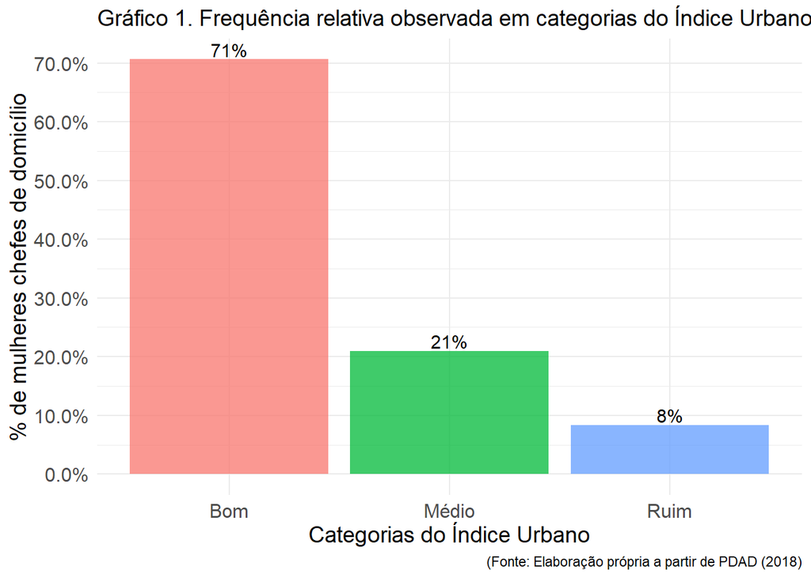

O Gráfico 1 mostra que, em geral, o índice urbano está dentro da categoria de “Bom”, com 71% dos domicílios chefiados por mulheres nesta faixa. Números menos expressivos encontram-se dentro da categoria de “Médio” ou “Ruim”. Portanto, no Distrito Federal, as famílias lideradas por mulheres têm uma qualidade de infraestrutura urbana considerada boa, segundo o índice. Contudo, é importando notar a frente esta variação de acordo com as Regiões Administrativas (Gráfico 7).

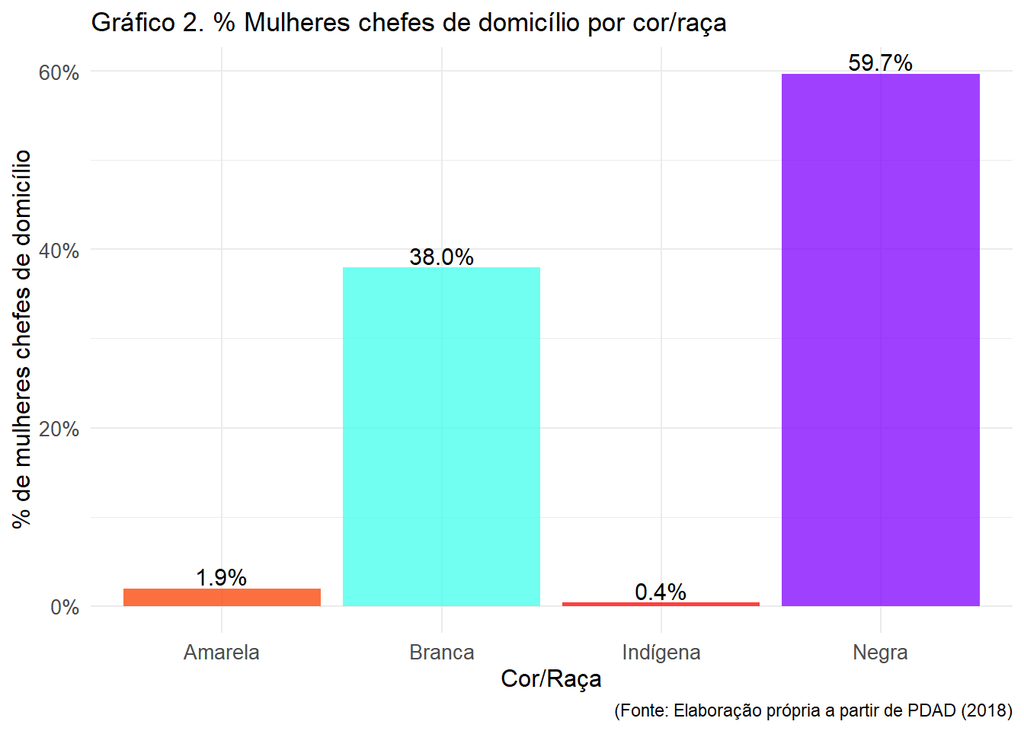

O Gráfico 2 evidencia que o percentual de mulheres chefes de domicílio varia segundo a categoria de raça. A grande maioria, isto é, 59,7% das mulheres responsáveis pelos domícilios no Distrito Federal são mulheres negras, enquanto 38% são brancas, 1,9%, amarelas, e 0,4%, indígenas. Essas cifras evidenciam uma significativa diferença de quais são as mulheres à frente das suas moradias.

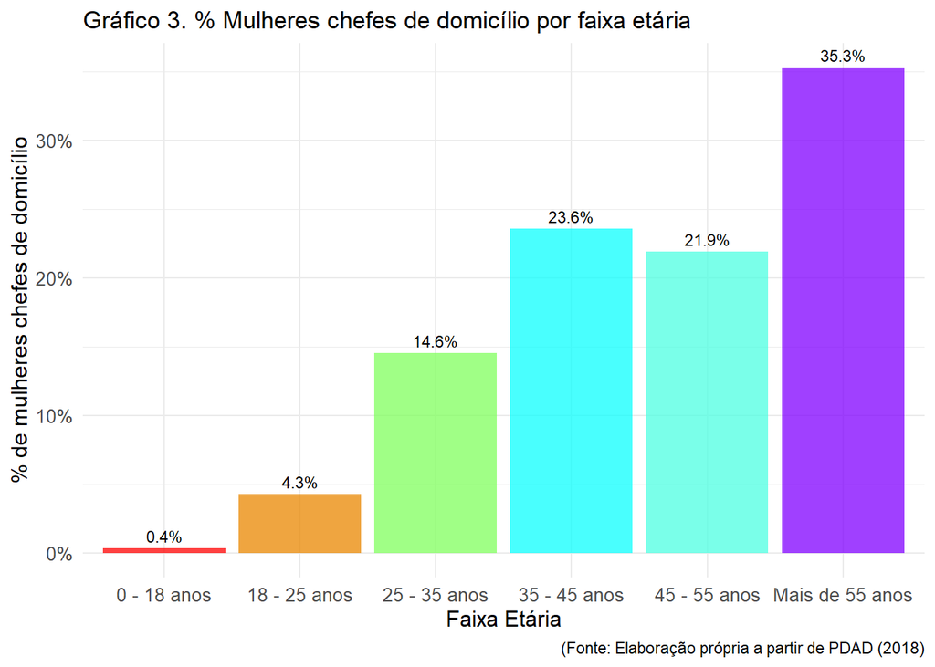

Em relação à faixa etária, abordada pelo Gráfico 3, 4,3% das mulheres chefes de domicílio tem entre 18 e 25 anos. O percentual aumenta para as mulheres entre 35 e 45 anos, com 23,6% do total. E uma quantidade expressiva (35,3%) dos domicílios são liderados por mulheres com mais de 55 anos.

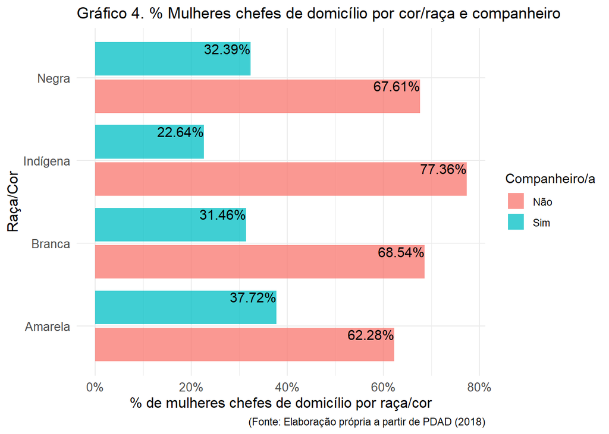

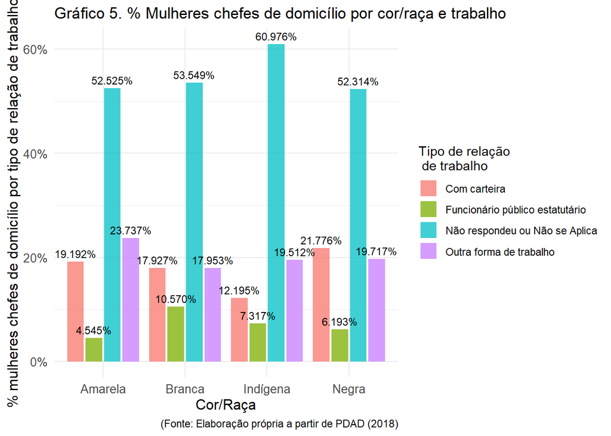

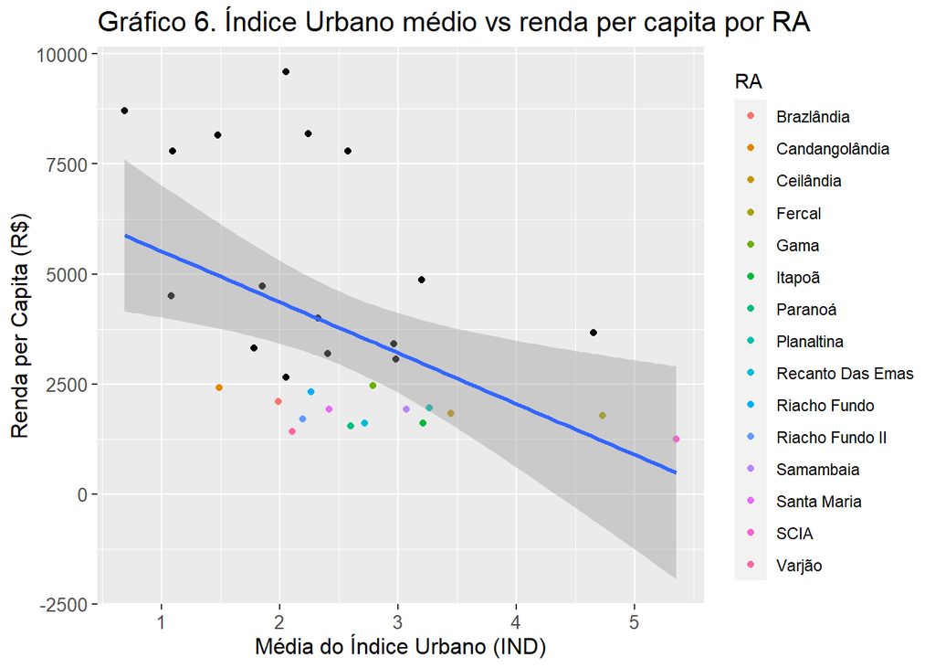

O Gráfico 6 confronta duas variáveis que, em princípio, parecem estar correlacionadas: a renda per capita e o Índice Urbano (IND) por Região Administrativa. E, de fato, constata-se que, à medida em que a renda per capita por RA cai, aumenta o valor médio do IND, o que denota maior precariedade infraestrutural em RAs de renda mais baixa.

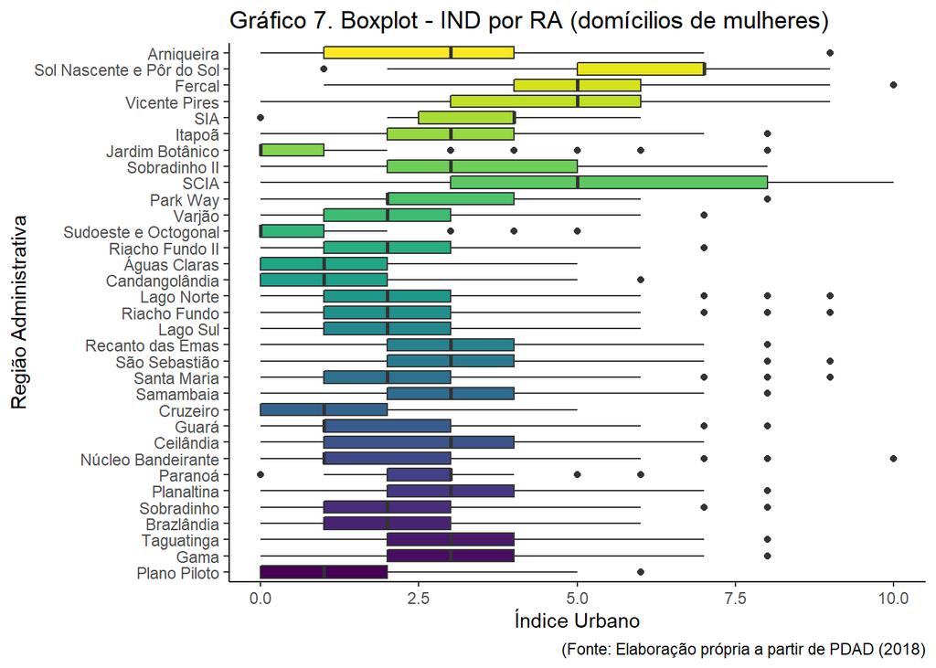

## 3.3 Inferências

### 3.3.1 Intervalo de Confiança:

O intervalo de confiança foi estimado a partir da média do Índice Urbano em relação ao gênero dos responsáveis da família.

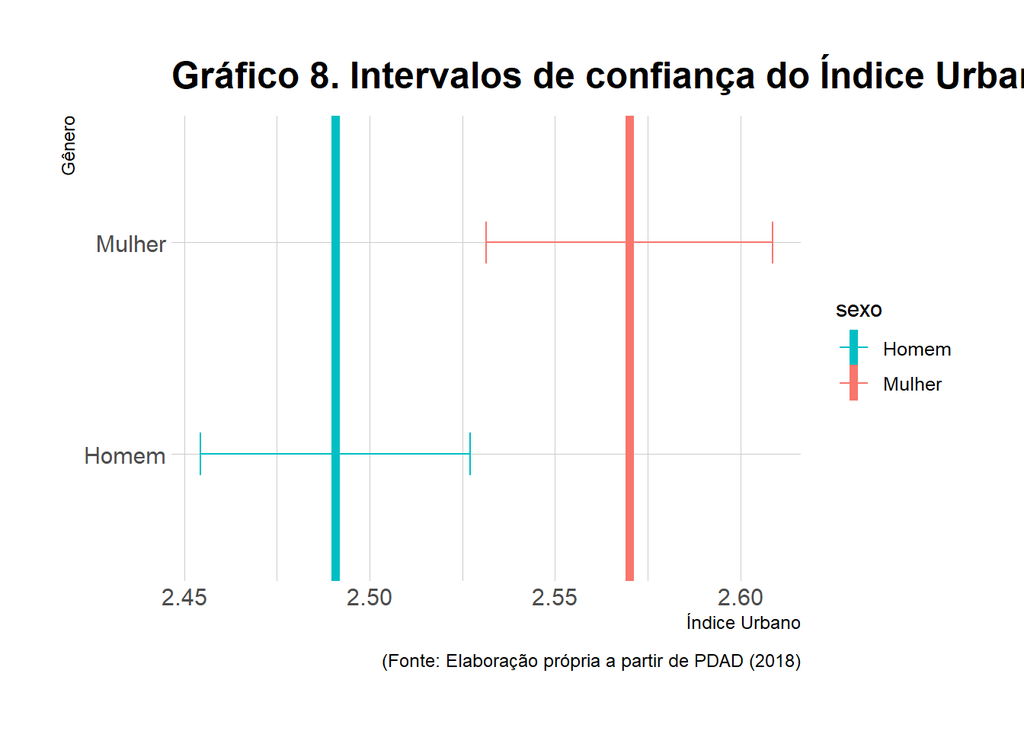

O intervalo de confiança para o gênero e índice urbano aponta que as mulheres possuem intervalo superior ao dos homens e os intervalos não estão sobrepostos, indicando diferença significativa entre eles, comprovada no teste de hipótese a seguir.

## 3.4 Testes de Hipóteses

### 3.4.1 Teste de Hipótese 1

- Testando média-IND(feminino) = média-IND(masculino)
- **Pergunta:** O gênero da pessoa responsável pelo domicílio faz diferença nos índices urbanos?
- **Variável dependente:** Índice Urbano
- **Variável independente:** Gênero da pessoa responsável pelo domicílio (Homem ou Mulher)

```
## # A tibble: 1 x 6
##   statistic   t_df p_value alternative lower_ci upper_ci
##       <dbl>  <dbl>   <dbl> <chr>          <dbl>    <dbl>
## 1      2.93 21527. 0.00338 two.sided     0.0263    0.132
```

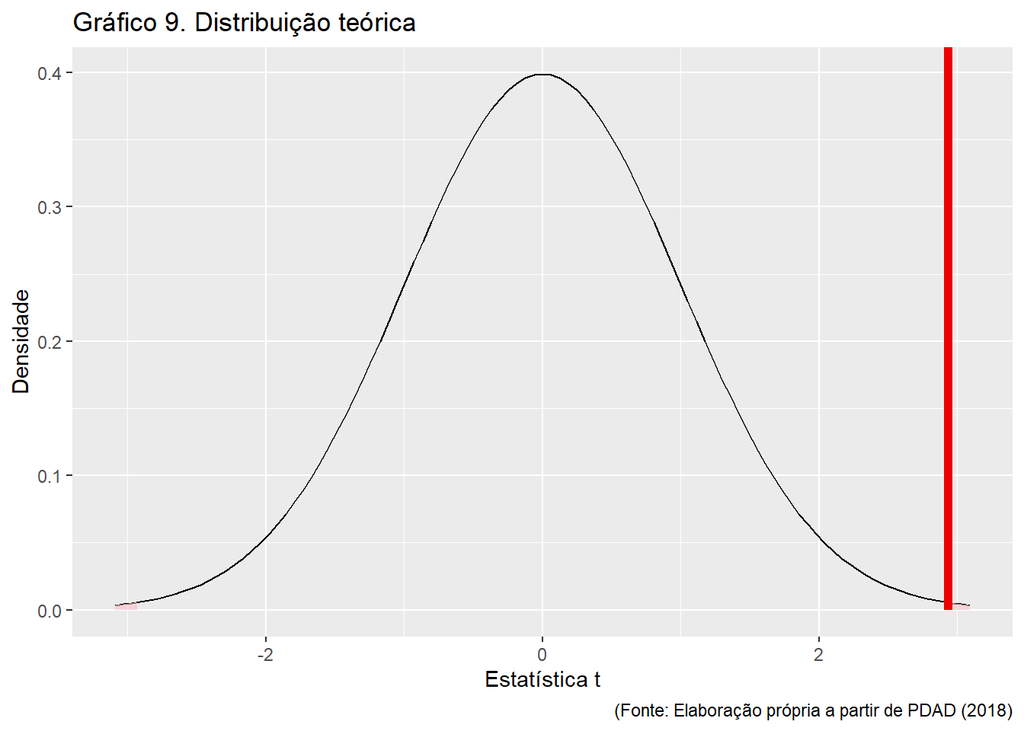

- **Análise do Teste de Hipótese:** Rejeita-se Ho, pois o p_value é menor que 0,05 (5%), então pode-se dizer que o índice médio urbano difere em relação ao gênero da pessoa responsável pelos domicílios, ao nível de 95% de confiança.

### 3.4.2 Teste de Hipótese 2

- **Teste de Análise de Variância (ANOVA):** Teste de média do índice urbano por raça
- **Pergunta:** A raça da pessoa responsável pelo domicílio faz diferença nos índices urbanos?

```
##                Df Sum Sq Mean Sq F value Pr(>F)
## raca            3   1031   343.7   87.02 <2e-16 ***
## Residuals   21904  86505     3.9
## ---
## Signif. codes:  0 '***' 0.001 '**' 0.01 '*' 0.05 '.' 0.1 ' ' 1
```

- **Resultado da Análise de Variância:** rejeita Ho, pois o p_value é menor que 0,05 (5%), então pode-se dizer que o índice médio urbano difere em relação as raças dos responsáveis pelos domicílios, ao nível de 95% de confiança.

# 4 Conclusão

O índice urbano de condições do domicílio apontou que as mulheres chefes de família estão em pior condições do que a dos homens. Quando as condições de habitação não são adequadas, os impactos na vida das mulheres são profundos, já que, tradicionalmente, elas exercem o papel social de cuidadoras da casa e da família. Em torno de 70% dos domicílios as mulheres chefiam seus domicílios sem cônjuge ou companheiro. As regiões de maior vulnerabilidade para os domicílios chefiados por mulheres são: Sol Nascente e Pôr do Sol, Fercal, Vicente Pires e SCIA (Estrutural).

# 5 Referências bibliográficas

Como fazer valer os direitos das mulheres à moradia? : (https://raquelrolnik.files.wordpress.com/2011/12/guia-mulheres-pt_ok.pdf)

Microdados PDAD 2018 :(http://codeplan.df.gov.br/codeplan-divulga-microdados-da-pdad-2018/)

Dados da PNAD-C/IBGE: (https://www.ibge.gov.br/estatisticas/sociais/trabalho/9127-pesquisa-nacional-por-amostra-de-domicilios.html)

CODEPLAN, 2020. Índice de Bem Estar Urbano (IBEU) do Distrito Federal, Codeplan (http://www.codeplan.df.gov.br/wp-content/uploads/2018/02/NM-O-%C3%8Dndice-de-Bem-Estar-Urbano-IBEU-do-Distrito-Federal.pdf)

FELKER-KANTOR. E; WOOD C. H. Female households and food insecurity in Brazil. Food insecurity, 2012. Disponível em: https://www.researchgate.net/publication/257788794_Female-headed_households_and_food_insecurity_in_Brazil.

OIT e PNUD, 2019. Trabalho e família rumo a formas de conciliação com corresponsabilidade Social.